# Simulation examples in the paper

Sangwon Hyun, Mattias Rolf Cape, Francois Ribalet, Jacob Bien

2022-04-20

# Setup

This script uses the flowmix package from github repository commit number `206aa0575ea2df56f168f42dc335acf002aed458` (https://github.com/sangwon-hyun/flowmix/commit/206aa0575ea2df56f168f42dc335acf002aed458).

# Simulation examples

## Figure 4

Figure 4 (left panel) is produced using this code:

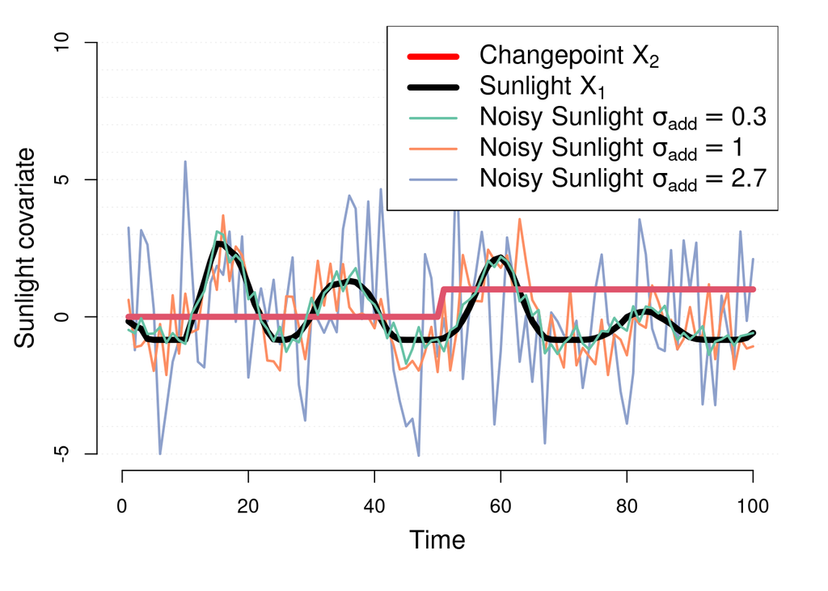

```r
## pdf(file.path(figdir, "noisy-covariates.pdf"), width=7, height=5)
obj = generate_data_1d_pseudoreal(nt = 200, beta_par = 0.3, p = 10)
par(mar = c(5.1, 4.1, 1.1, 2.1))
par(mgp = c(2.5, 1, 0))
cex.fac = 1.3
par(cex.lab = cex.fac)
lwd = 2
cols = RColorBrewer::brewer.pal(4, "Set2")
matplot(NA, ylab="Sunlight covariate", xlab="Time", axes=FALSE,ylim=c(-5, 10), xlim = c(0,100))
abline(h=seq(from = -5, to = 10), lwd=.5, col='grey90', lty=3)
set.seed(0)
lines(obj$X[,1] + rnorm(nrow(obj$X), 0, 2.7), type='l', lwd=lwd, lty=1,  col=cols[3],)
lines(obj$X[,1] + rnorm(nrow(obj$X), 0, 1), type='l', lwd=lwd, lty=1,  col=cols[2],)
lines(obj$X[,1] + rnorm(nrow(obj$X), 0, 0), type='l', lwd=5, lty=1,  col=1)##cols[1],)
lines(obj$X[,2], type='l', lwd=5, lty=1,  col=2)
lines(obj$X[,1] + rnorm(nrow(obj$X), 0, 0.3), type='l', lwd=lwd, lty=1,  col=cols[1],)
axis(1)
axis(2)
legend("topright", col=c("red","black", cols[1:3]), lwd=c(5,5,rep(lwd,3)), lty=1,
       legend= c(expression(Changepoint~X[2]), expression(Sunlight~X[1]),
                 expression(Noisy~Sunlight~sigma["add"]==0.3),
                 expression(Noisy~Sunlight~sigma["add"]==1),
                 expression(Noisy~Sunlight~sigma["add"]==2.7)),
       bg="white",
       cex = cex.fac)
```

```r
## legend("topright", col=c(""))
## graphics.off()
```

Figure 4 (right panel) is produced using this code:

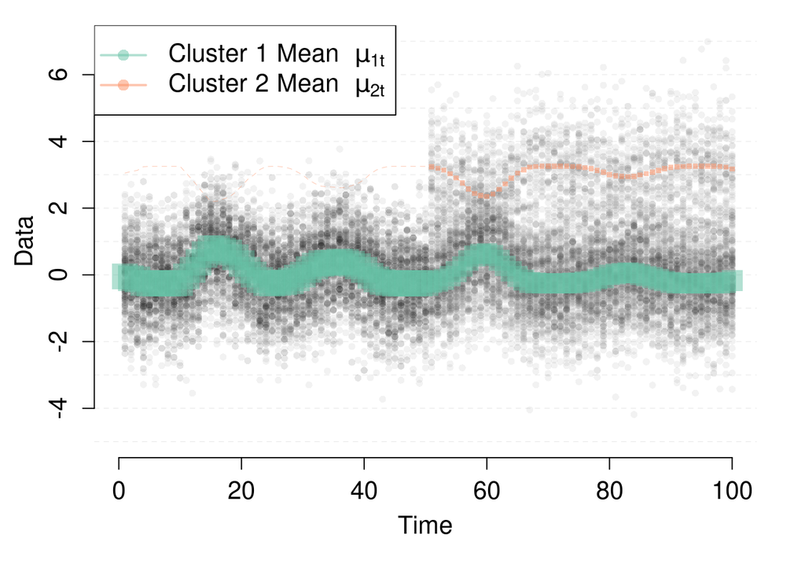

```r
obj = generate_data_1d_pseudoreal(nt = 200, beta_par = 0.3, p = 10)
list2env(obj, envir = globalenv()) %>% invisible()
## print(xtable::xtable(cbind(alpha, beta)) )

ymat = do.call(rbind, lapply(ylist, as.numeric))
## pdf(file=file.path(figdir, "noisy-covariates-data.pdf"), width=7, height=5)
par(mar = c(5.1, 4.1, 1.1, 2.1))
par(mgp = c(2.5, 1, 0))
cex.fac = 1.3
par(cex.lab=cex.fac)
matplot(NA, xlim=c(0,100), ylim=c(-5, 7), axes=FALSE, ylab="Data", xlab="Time")
abline(h=seq(from=-30, to=30, by=1), lwd=.5, col='grey90', lty=2)
matpoints(ymat, type='p', pch=16, col=rgb(0,0,0,0.05), cex=0.8)
axis(1, cex.axis=cex.fac); axis(2, tick=TRUE, label=TRUE, cex.axis=cex.fac)
cols = RColorBrewer::brewer.pal( 3, "Set2")
cols = sapply(cols, function(col) adjustcolor( col, alpha.f = 0.5))
matlines(mnmat, type='l', lwd=.5, col=cols, lty=2)
points(mnmat[,1], type='p', lwd=2, col=cols[1], pch=15, cex=prob[,1]*3)
points(mnmat[,2], type='p', lwd=2, col=cols[2], pch=15, cex=prob[,2]*3)
legend("topleft", col=cols, lwd=2, pch=16, lty=1,
       legend=c(expression(Cluster~1~Mean~~mu["1t"]),
                expression(Cluster~2~Mean~~mu["2t"])),
       bg = "white",
       cex=cex.fac)
```

```r
## graphics.off()
```

## Figure 6

Figure 6 is produced using this code:

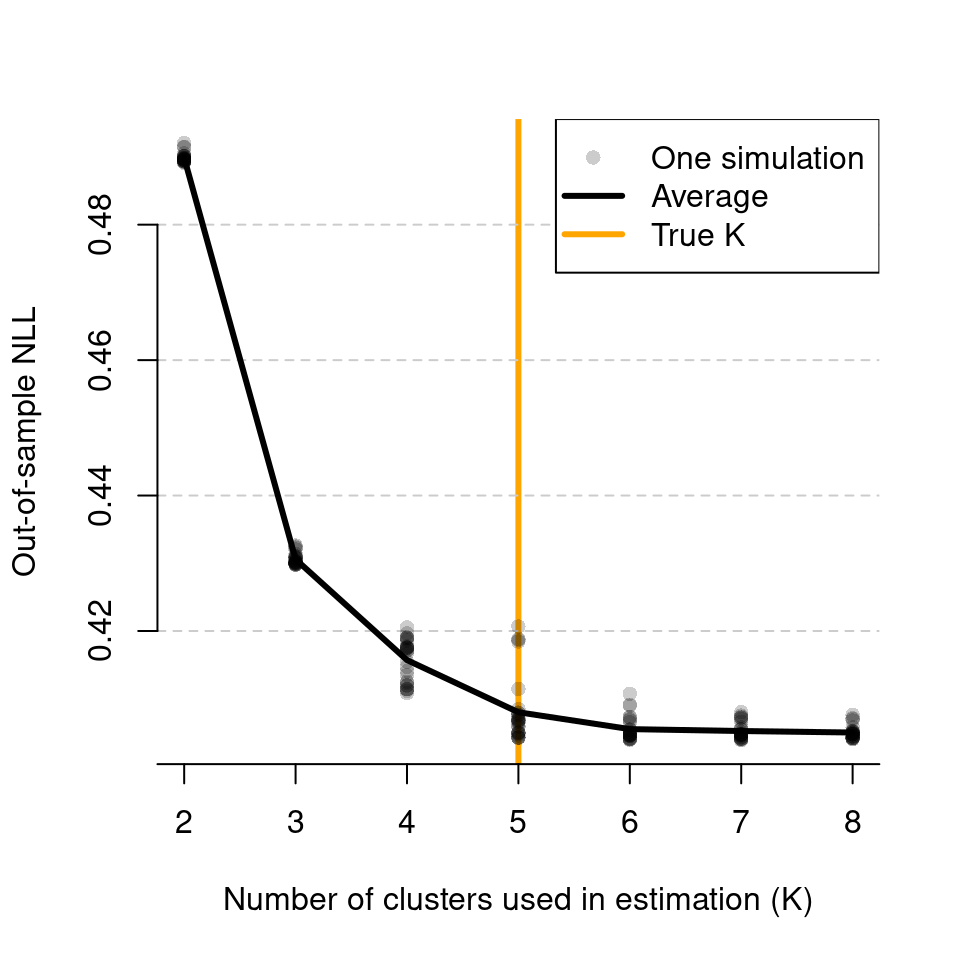

```r
numclusts = c(2,3,4,5,6,7,8)
nsim = 30
probs = c(0.05, 0.95, 0.25, 0.75)

## Empty CV score objects
avg_cvscores = rep(NA, length(numclusts))
quantile_cvscores = matrix(NA, nrow = length(numclusts), ncol = 4)
all_cvscores = matrix(NA, nrow = length(numclusts), ncol = nsim)

## Empty out-of-sample score objects
avg_oos_scores = rep(NA,  length(numclusts)) ## new
quantile_oos_scores = matrix(NA, nrow = length(numclusts), ncol = 4)
all_oos_scores = matrix(NA, nrow = length(numclusts), ncol = nsim)

## Generate LARGE new dataset (large = large n_t$) from new model
## datadir = "~/repos/cruisedat/export"
datadir = "../paper-data"
nt = 3000
datobj = generate_data_1d_pseudoreal_from_cv(datadir = datadir, nt = nt)
## datobj$countslist = lapply(1:TT, function(tt) rep(1, nt)) ## not needed

blocktype = 2
datatype = 9
for(iclust in 1:length(numclusts)){
  numclust = numclusts[iclust]

  ## This is the /original/ way to load results.
  ## subfolder = paste0("blockcv-", blocktype, "-", datatype, "-", numclust)
  ## destin = file.path(datadir, folder)
  ## load(file = file.path(destin, "summary", "bestreslist.Rdata"))

  ## Easier way to load results
  load(file = file.path(datadir, "simulation",
                        paste0("bestreslist-numclust-", numclust, ".Rdata")))

  nsim = length(bestreslist)
  for(isim in 1:nsim){

    ## Load model
    bestres = bestreslist[[isim]]
    class(bestres) = "flowmix"
    bestres$prob = bestres$pie
    if(is.null(bestres)) next

    ## Calculate out-of-sample scores (oos)
    all_oos_scores[iclust, isim] = objective_newdat(ylist = datobj$ylist,
                                                    countslist = datobj$countslist,
                                                    res  =  bestres)
  }
}

## Calculate the average and quantiles
for(iclust in 1:length(numclusts)){
  numclust = numclusts[iclust]
  avg_oos_scores[iclust] = mean(all_oos_scores[iclust,], na.rm=TRUE)
  quantile_oos_scores[iclust,] = quantile(all_oos_scores[iclust,], probs = probs,
                                      na.rm=TRUE) ## middle 90% quantile.
}

## Labeling quantile CV scores
rownames(quantile_cvscores) = numclusts
colnames(quantile_cvscores) = probs
rownames(all_cvscores) = numclusts
names(avg_cvscores) = numclusts

## Labeling out of sample scores
rownames(quantile_oos_scores) = numclusts
colnames(quantile_oos_scores) = probs
rownames(all_oos_scores) = numclusts
names(avg_oos_scores) = numclusts

## pdf(file=file.path(figdir, "numclusts-cvscores-new.pdf"), width=5, height=5)
par(mar=c(5.1,4.1,3.1,2.1))
all_numclusts = 2:8
plot(NA,
     xlim = c(2, 8),
     ylim = range(all_oos_scores, na.rm=TRUE),
     ylab = "Out-of-sample NLL",
     xlab = "Number of clusters used in estimation (K)",
     axes=FALSE)
abline(v=5, col='orange', lwd=3)
abline(h=seq(from=0.40, to=0.48, by=0.02), col='grey80', lty=2)
## text(x=5, y=0.47, label="True underlying K")
legend('topright', col=c(rgb(0,0,0,0.2), 'black', 'orange'),
       lwd = c(NA, 3,3),
       pch = c(16, NA,NA),
       legend = c("One simulation", "Average", "True K"),
       bg = "white")
axis(1, at=1:10);
axis(2)
pch = 1:30
for(iclust in 1:length(numclusts)){
  numclust = numclusts[iclust]
  points(y = all_oos_scores[iclust, ],
         x = rep(numclust, ncol(all_oos_scores)),
         ## type = 'p',
         col = rgb(0,0,0,0.2),
         cex = 1,
         ## pch = sapply(1:30, toString)
         pch = 16
         )
}
lines(y = avg_oos_scores,
      x = numclusts,
      lwd = 3, type = 'l')
```

```r
## graphics.off()
```

## Figure 5

Figure 5 is produced using this code:

The simulation results are saved in files named `simulations/bestreslist-noise-80.Rdata` through `simulations/bestreslist-noise-89.Rdata`, and are produced from the script in `paper-code/simulations-noisy-covariates.Rmd`.

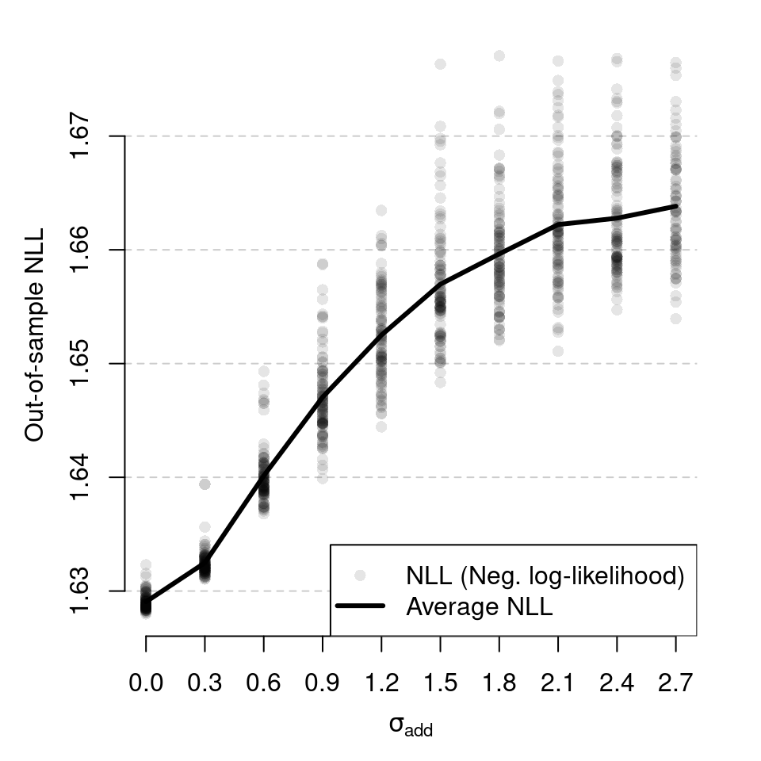

```r
## Load simulation results
datatypes = c(80:89)
sigmalist = seq(from=0,to=2.7, by=0.3)
lwd = 3
ooslist =  outsample_loglik(2, datatypes, 2)
list2env(ooslist, envir = .GlobalEnv) %>% invisible()

## pdf(file=file.path(figdir, "noisy-covariate-fit.pdf"), width=5, height=5)
par(mar = c(4.1, 4.1, 1.1, 2.1))
par(mgp = c(2.5, 1, 0))
plot(NA,
     ylab = "Out-of-sample NLL",
     xlab = expression(sigma["add"]),
     ylim = range(all_oos, na.rm=TRUE),
     ## ylim = range(c(the_best_loglik - 0.005, all_oos), na.rm=TRUE),
     xlim = range(sigmalist),
     axes = FALSE)
abline(h = seq(from=1.6, to=1.7, by = 0.01), col ='grey80', lty=2)
## abline(h = the_best_loglik, lwd=3, col='orange')
## text(y = the_best_loglik * 1.003, x=2, labels="Best attainable \n Neg. log likelihood (NLL)")
matlines(y = all_oos,
        x = sigmalist,
        type='p', pch=16, col=rgb(0,0,0,0.1))
axis(2); axis(1, at=sigmalist)##, las=3)##[c(1,2*(1:5))]);
lines(y = avg_oos,
      x = sigmalist,
      lwd=3, type='l')
legend("bottomright",
       col = c(rgb(0,0,0,0.1), "black"),
       lwd = c(NA, lwd),
       pch = c(16, NA),
       legend = c("NLL (Neg. log-likelihood)", "Average NLL"),
       bty="o",
       border="white",
       bg="white")
```

```r
## graphics.off()
```

## Figure 18

Figure 18 (left panel) is produced using this code:

(The original script to run the simulations is in `paper-code/aoas-revision/bin.Rmd`)

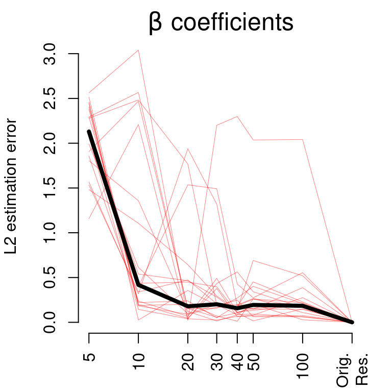

```r
## Load all the results from simulations
nsim = 20
list_of_cvreslist = list()
Blist = c(5, 10, 20, 30, 40, 50, 100, 10000)
for(ii in 1:length(Blist)){
  cvreslist = list()
  B = Blist[ii]
  for(isim in 1:nsim){
    folder = paste0("bin-B-", B)
    cvres = tryCatch({
      readRDS(file.path(datadir, "simulation/effect-of-binning", folder, "summaries", paste0("summary-", isim, ".RDS")))
    }, error=function(e){ return(NULL) })
    cvreslist[[isim]] = cvres
  }
  list_of_cvreslist[[ii]] = cvreslist
}
names(list_of_cvreslist) = Blist

## Now, measure the L2 distance from the optimum OF THE BETAS
type = "beta"
l2err_list = list()
for(isim in 1:20){
  reslist = list()
  for(ii in 1:length(Blist)){
    B = Blist[[ii]]
    ## Collect all the results
    res = (list_of_cvreslist[[ii]][[isim]])$bestres
    ## Sort by size
    res = res %>% reorder_clust()
    reslist[[ii]] = res
  }
  coeflist = lapply(reslist, function(a) a[[type]])
  names(coeflist) = Blist
  coef_full_res = coeflist[["10000"]]
  if(type == "beta"){
    coef_err = lapply(coeflist, function(coef){
      ## coef[[iclust]] - coef_full_res[[iclust]]
      do.call(cbind, coef) - do.call(cbind, coef_full_res)
    })
  }
  if(type == "alpha"){
    coef_err = lapply(coeflist, function(coef){
      coef- coef_full_res
    })
  }
  ## do.call(cbind, beta_err) %>% t() %>% matplot(type='l', lty=1)
  l2err = sapply(coef_err , function(a) sqrt(sum(a^2)))
  l2err_list[[isim]] = l2err
}

par(mar=c(3,4,2,1.5))
ylab = "L2 estimation error"
xlab = "Number of bins (B)"
Blist_copy = Blist
Blist_copy[8] = 200
l2err_list %>% do.call(cbind, .) %>% matplot(x=Blist_copy, type='l', lty=1, col='red' %>% adjustcolor(alpha=0.5), lwd=.5, log="x", axes=FALSE, ylab=ylab, xlab=xlab)
l2err_list %>% do.call(cbind, .) %>% apply(., 1, median) %>% matlines(x=Blist_copy, type='l', lty=1, lwd=4, col='black', log="x")
axis(2)
Blist_copy_char = Blist_copy
Blist_copy_char[8] = "Orig.\nRes."
axis(1, at=Blist_copy, labels=Blist_copy_char, las=3)
if(type=="alpha")mtext(text=expression(alpha~coefficients), cex=1.5)
if(type=="beta")mtext(text = expression(beta~coefficients), cex=1.5)
```

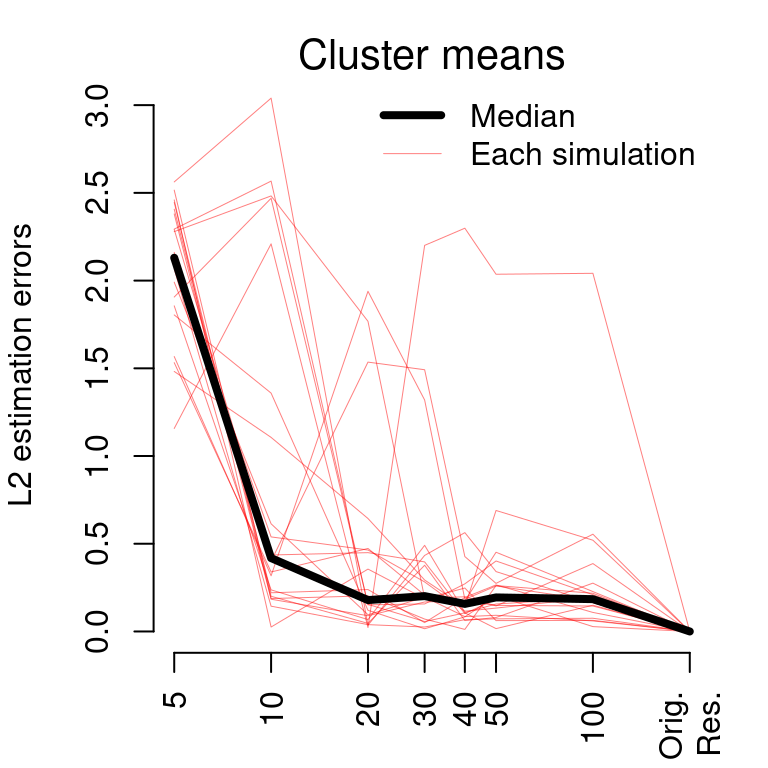

```r
par(mar=c(3,4,2,1.5))
ylab = "L2 estimation errors"
xlab = "Number of bins (B)"
Blist_copy = Blist
Blist_copy[8] = 200
l2err_list %>% do.call(cbind, .) %>% matplot(x=Blist_copy, type='l', lty=1, col='red' %>% adjustcolor(alpha=0.5), lwd=.5, log="x", axes=FALSE, ylab=ylab, xlab=xlab)
l2err_list %>% do.call(cbind, .) %>% apply(., 1, median) %>% matlines(x=Blist_copy, type='l', lty=1, lwd=4, col='black', log="x")
axis(2)
Blist_copy_char = Blist_copy
Blist_copy_char[8] = "Orig.\nRes."
axis(1, at=Blist_copy, labels=Blist_copy_char, las=3)
mtext(text="Cluster means", cex=1.3, side=3)
legend("topright", lwd=c(4, 0.5), col=c("black", "red" %>% adjustcolor(alpha=0.5)), lty=1, legend=c( "Median", "Each simulation"), bty="n")
```

## Figure 19

Figure 19 (top row) is produced using the following code:

(The code used to produce simulations for figure 19 is in `paper-code/heavytail-skewed.Rmd`.)

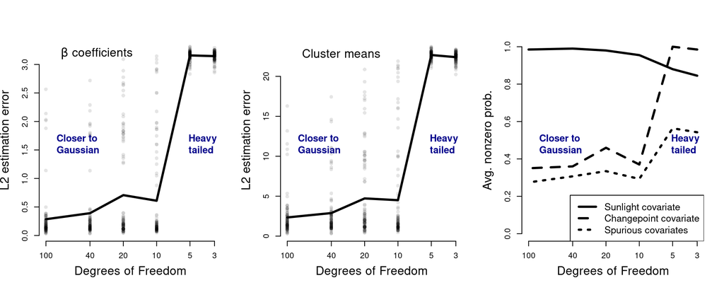

```r
l2_errs_list = readRDS(file = file.path(datadir, "simulation", "heavytail-simulation-results.RDS"))

## Make error plot
## pdf(file = file.path(figdir, "heavytail-data-performance.pdf"), width=10, height=4)
par(mfrow=c(1,3))
par(cex.lab=1.5)
ylab = "L2 estimation error"
## xlab = expression(shape~parameter~(alpha))
xlab = expression(Degrees~of~Freedom)
lwd = 3
ylims = NULL
cex = 1.2
nsim = 100
dfs = c(3,5,10,20,40,100)
for(ii in 1:5){

  if(ii %in% c(1,2)){
    l2_errs_list %>% .[[ii]] %>%  matplot(x = dfs, pch = 16, col = rgb(0, 0, 0, 0.1),
                                          log = "x",
                                          ylab = ylab, xlab = xlab,
                                          axes = FALSE,
                                          xlim = range(dfs) %>% rev())
    axis(1, at = dfs); axis(2)##, at = seq(from=1,to=3.5, by=0.01))
    l2_errs_list %>% .[[ii]]  %>% t() %>% apply(2, mean, na.rm = TRUE) %>% lines(x = dfs,
                                                                                 lwd = lwd, col = 'black',
                                                                                 type = 'l')
  }
  if(ii == 3){
    (l2_errs_list %>% .[[ii]] / 2) %>% t() %>% apply(2, mean, na.rm = TRUE) %>%
      plot(y=., x = dfs, type='l',
           lwd = lwd,
           ylab = "Avg. nonzero prob.",
           xlab = xlab,
           ylim = c(0,1),
           axes = FALSE,
           xlim = range(dfs) %>% rev(),
           log="x")
    axis(1, at = dfs); axis(2)
  }
  if(ii ==4){
    (l2_errs_list %>% .[[ii]] / 2) %>% t() %>% apply(2, mean, na.rm = TRUE) %>%
      lines(y=., x = dfs, type='l',lwd = lwd,
            lty=2)
  }
  if(ii == 5){
    (l2_errs_list %>% .[[ii]] / 16) %>% t() %>%  apply(2, mean, na.rm = TRUE) %>%
      lines(y=., x = dfs, type='l', lwd = lwd, ylab = expression(average~of~nonzero~probability), xlim = range(dfs),ylim = c(0,1),
            lty = 3)
  }
  text.font = 1.2
  text.col = "darkblue"
  if(ii %in% c(1,2,3)){
    legend('left', bty = 'n', legend="Closer to \nGaussian", cex=cex, text.font = 2, text.col = text.col)
    legend('right', bty = 'n', legend="Heavy\ntailed", cex=cex, text.font = 2, text.col = text.col)
  }
  if(ii %in% c(1,2)){
    if(ii==1) lg = expression(beta~coefficients)
    if(ii==2) lg = expression(Cluster~means)
    legend("topleft", bty='n', cex=1.5, legend=lg)
  }
  if(ii == 3){
    legend("bottomright", lwd=3, lty=c(1,2,3), legend=c("Sunlight covariate",
                                                        "Changepoint covariate",
                                                        "Spurious covariates"),
           cex = 1.2)
  }
}
```

Figure 19 (bottom row) is produced using the following code:

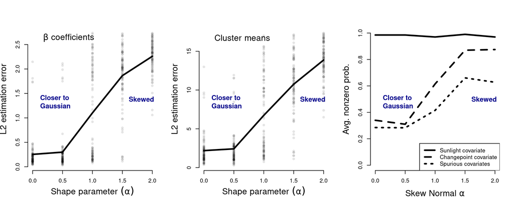

```r
l2_errs_list = readRDS(file = file.path(datadir, "simulation", "skewed-simulation-results.RDS"))

## Make error plot
## pdf(file = file.path(figdir, "skewed-data-performance.pdf"), width=10, height=4)
par(mfrow=c(1,3))
par(cex.lab = 1.5)
ylab = "L2 estimation error"
xlab = expression(Shape~parameter~(alpha))
lwd = 3
ylims = NULL
cex = 1.2
alphas = seq(from=0, to =2, by = 0.5)
for(ii in 1:5){
  if(ii %in% c(1,2)){
    l2_errs_list %>% .[[ii]] %>%  matplot(x = alphas, pch = 16, col = rgb(0, 0, 0, 0.1),
                                          ## log = "x",
                                          ylab = ylab, xlab = xlab,
                                          axes = FALSE,
                                          xlim = range(alphas))
    axis(1, at = alphas); axis(2)##, at = seq(from=1,to=3.5, by=0.01))
    l2_errs_list %>% .[[ii]]  %>% t() %>% apply(2, mean, na.rm = TRUE) %>% lines(x = alphas,
                                                                                 lwd = lwd, col = 'black',
                                                                                 type = 'l')
  }
  if(ii == 3){
    (l2_errs_list %>% .[[ii]] / 2) %>% t() %>% apply(2, mean, na.rm = TRUE) %>%
      plot(y=., x = alphas, type='l',
           lwd = lwd,
           ylab = "Avg. nonzero prob.",
           xlab = expression(Skew~Normal~alpha),
           xlim = range(alphas),
           ylim = c(0,1),
           axes = FALSE)
    axis(1); axis(2)
  }
  if(ii ==4){
    (l2_errs_list %>% .[[ii]] / 2) %>% t() %>% apply(2, mean, na.rm = TRUE) %>%
      lines(y=., x = alphas, type='l',lwd = lwd,
            lty=2)
  }
  if(ii == 5){
    (l2_errs_list %>% .[[ii]] / 16) %>% t() %>%  apply(2, mean, na.rm = TRUE) %>%
      lines(y=., x = alphas, type='l', lwd = lwd, ylab = expression(average~of~nonzero~probability), xlim = range(alphas),ylim = c(0,1),
            lty = 3)
  }
  text.font = 1.2
  text.col = "darkblue"
  if(ii %in% c(1,2,3)){
    legend('left', bty = 'n', legend="Closer to \nGaussian", cex=cex, text.font = 2, text.col = text.col)
    legend('right', bty = 'n', legend="Skewed", cex=cex, text.font = 2, text.col = text.col)
  }
  if(ii %in% c(1,2)){
    if(ii==1) lg = expression(beta~coefficients)
    if(ii==2) lg = expression(Cluster~means)
    legend("topleft", bty='n', cex=1.5, legend=lg)
  }
  if(ii == 3){
    legend("bottomright", lwd=3, lty=c(1,2,3), legend=c("Sunlight covariate",
                                                        "Changepoint covariate",
                                                        "Spurious covariates"))
  }
}
```